# Thesis

ENOCK OSEI

## Demography

| Characteristic | N = 4011 |
| --- | --- |
| Age |  |
| 18 - 24 years | 121 (30%) |
| 25 - 30 years | 171 (43%) |
| 31 - 40 years | 50 (12%) |
| 41 - 50 years | 36 (9.0%) |
| 51 - 60 years | 12 (3.0%) |
| 61 and above | 3 (0.7%) |
| under 18 | 8 (2.0%) |
| Gender |  |
| Female | 170 (42%) |
| Male | 231 (58%) |
| Education Level |  |
| Bachelors degree | 139 (35%) |
| High school certififcate | 107 (27%) |
| HND/diploma | 60 (15%) |
| Junior High certififcate | 36 (9.0%) |
| No formal Education | 25 (6.2%) |
| Postgraduate | 34 (8.5%) |
| Employment status |  |
| Formally Employed | 140 (35%) |
| Self Employed | 107 (27%) |
| Student | 107 (27%) |
| Unemployed | 47 (12%) |
| Marital status |  |
| Cohabitation | 15 (3.7%) |
| Divorced | 3 (0.7%) |
| Married | 115 (29%) |
| separated | 1 (0.2%) |
| Single | 267 (67%) |
| Car ownership |  |
| no | 1 (0.2%) |
| No | 310 (77%) |
| Yes | 90 (22%) |
| Motor/Bicycle Ownership |  |
| no | 1 (0.2%) |
| No | 338 (84%) |
| Yes | 62 (15%) |
| Average monthly household income |  |
| 1001 - 1500 cedis | 32 (8.0%) |
| 101 - 500 cedis | 113 (28%) |
| 1501 - 2500 cedis | 65 (16%) |
| 2501 - 3500 cedis | 18 (4.5%) |
| 3500 - above cedis | 13 (3.2%) |
| 501 - 1000 cedis | 96 (24%) |
| less 100 cedis | 64 (16%) |

1n (%)

## Primary Trips Before COvid By Gender

| Characteristic | Gender Female, N = 1701 | Gender Male, N = 2311 | Education Bachelors degree, N = 1391 | Education High school certififcate, N = 1071 | Education HND/diploma, N = 601 | Education Junior High certififcate, N = 361 | Education No formal Education, N = 251 | Education Postgraduate, N = 341 |
| --- | --- | --- | --- | --- | --- | --- | --- | --- |
| Primary trip |  |  |  |  |  |  |  |  |
| others | 18 (11%) | 25 (11%) | 16 (12%) | 6 (5.6%) | 15 (25%) | 3 (8.3%) | 2 (8.0%) | 1 (2.9%) |
| shopping | 17 (10%) | 16 (6.9%) | 12 (8.6%) | 12 (11%) | 2 (3.3%) | 2 (5.6%) | 2 (8.0%) | 3 (8.8%) |
| study | 60 (35%) | 64 (28%) | 43 (31%) | 46 (43%) | 11 (18%) | 7 (19%) | 3 (12%) | 14 (41%) |
| work | 75 (44%) | 126 (55%) | 68 (49%) | 43 (40%) | 32 (53%) | 24 (67%) | 18 (72%) | 16 (47%) |

1n (%)

## Frequency of Primary Trips Before and During Covid

| Characteristic | Before Covid N = 4011 | During Covid N = 4011 |
| --- | --- | --- |
| Work trips |  |  |
| 1 trip/week | 42 (10%) | 46 (11%) |
| 2 trips/week | 27 (6.7%) | 56 (14%) |
| 3 trips/week | 16 (4.0%) | 20 (5.0%) |
| 4 trip/week | 12 (3.0%) | 13 (3.2%) |
| 5 or more trips/week | 169 (42%) | 98 (24%) |
| never | 135 (34%) | 168 (42%) |
| Study trips |  |  |
| 1 trip/week | 71 (18%) | 67 (17%) |
| 2 trips/week | 43 (11%) | 46 (11%) |
| 3 trips/week | 20 (5.0%) | 27 (6.7%) |
| 4 trip/week | 18 (4.5%) | 16 (4.0%) |
| 5 or more trips/week | 86 (21%) | 52 (13%) |
| never | 163 (41%) | 193 (48%) |
| Shopping trips |  |  |
| 1 trip/week | 96 (24%) | 116 (29%) |
| 2 trips/week | 89 (22%) | 36 (9.0%) |
| 3 trips/week | 24 (6.0%) | 14 (3.5%) |
| 4 trip/week | 14 (3.5%) | 6 (1.5%) |
| 5 or more trips/week | 8 (2.0%) | 7 (1.7%) |
| never | 170 (42%) | 222 (55%) |
| Recreational trips |  |  |
| 1 trip/week | 114 (28%) | 81 (20%) |
| 2 trips/week | 40 (10.0%) | 21 (5.2%) |
| 3 trips/week | 21 (5.2%) | 8 (2.0%) |
| 4 trip/week | 8 (2.0%) | 10 (2.5%) |
| 5 or more trips/week | 11 (2.7%) | 6 (1.5%) |
| never | 207 (52%) | 275 (69%) |
| Social activity trips |  |  |
| 1 trip/week | 151 (38%) | 98 (24%) |
| 2 trips/week | 36 (9.0%) | 36 (9.0%) |
| 3 trips/week | 22 (5.5%) | 11 (2.7%) |
| 4 trip/week | 18 (4.5%) | 8 (2.0%) |
| 5 or more trips/week | 19 (4.7%) | 7 (1.7%) |
| never | 155 (39%) | 241 (60%) |

1n (%)

## Frequency of Online Activities Before and During Covid

| Characteristic | Before Covid N = 4011 | During Covid N = 4011 |
| --- | --- | --- |
| Online learning |  |  |
| 1/week | 79 (20%) | 62 (15%) |
| 2/week | 40 (10.0%) | 48 (12%) |
| 3/week | 24 (6.0%) | 27 (6.7%) |
| 4/week | 7 (1.7%) | 9 (2.2%) |
| 5/more/week | 34 (8.5%) |  |
| never | 217 (54%) | 187 (47%) |
| 5 or more/week |  | 68 (17%) |
| Online shopping |  |  |
| 1/week | 48 (12%) | 59 (15%) |
| 2/week | 38 (9.5%) | 28 (7.0%) |
| 3/week | 21 (5.2%) | 17 (4.2%) |
| 4/week | 7 (1.7%) | 9 (2.2%) |
| 5/more/week | 18 (4.5%) |  |
| never | 269 (67%) | 248 (62%) |
| 5 or more/week |  | 40 (10.0%) |
| Teleworking |  |  |
| 1/week | 69 (17%) | 65 (16%) |
| 2/week | 36 (9.0%) | 24 (6.0%) |
| 3/week | 16 (4.0%) | 24 (6.0%) |
| 4/week | 8 (2.0%) | 10 (2.5%) |
| 5/more/week | 6 (1.5%) |  |
| never | 266 (66%) | 262 (65%) |
| 5 or more/week |  | 16 (4.0%) |

1n (%)

| Characteristic | Before Covid N = 4011 | During Covid N = 4011 |
| --- | --- | --- |
| Primary trip |  |  |
| others | 43 (11%) | 43 (11%) |
| shopping | 33 (8.2%) | 33 (8.2%) |
| study | 124 (31%) | 124 (31%) |
| work | 201 (50%) | 201 (50%) |

1n (%)

## Frequency of distance traveled Before and During Covid by Gender

| Characteristic | Before Covid Female, N = 1701 | Before Covid Male, N = 2311 | During Covid Female, N = 1701 | During Covid Male, N = 2311 |
| --- | --- | --- | --- | --- |
| Distance travel |  |  |  |  |
| 0 - 5km | 32 (19%) | 30 (13%) | 68 (40%) | 55 (24%) |
| 10.01 - 15km | 35 (21%) | 41 (18%) | 18 (11%) | 31 (13%) |
| 15.01 - 20km | 13 (7.6%) | 11 (4.8%) | 7 (4.1%) | 8 (3.5%) |
| 20.01 - 30km | 32 (19%) | 40 (17%) | 10 (5.9%) | 20 (8.7%) |
| 30.01km and above | 15 (8.8%) | 37 (16%) | 8 (4.7%) | 28 (12%) |
| 5.01 - 10km | 43 (25%) | 72 (31%) | 59 (35%) | 89 (39%) |

1n (%)

## Frequency of distance traveled Before and During Covid by Household car ownership

| Characteristic | Before Covid No, N = 3101 | Before Covid Yes, N = 901 | During Covid No, N = 3101 | During Covid Yes, N = 901 |
| --- | --- | --- | --- | --- |
| Distance travel |  |  |  |  |
| 0 - 5km | 49 (16%) | 13 (14%) | 99 (32%) | 24 (27%) |
| 10.01 - 15km | 57 (18%) | 18 (20%) | 40 (13%) | 9 (10%) |
| 15.01 - 20km | 21 (6.8%) | 3 (3.3%) | 7 (2.3%) | 8 (8.9%) |
| 20.01 - 30km | 54 (17%) | 18 (20%) | 29 (9.4%) | 1 (1.1%) |
| 30.01km and above | 44 (14%) | 8 (8.9%) | 28 (9.0%) | 8 (8.9%) |
| 5.01 - 10km | 85 (27%) | 30 (33%) | 107 (35%) | 40 (44%) |

1n (%)

## Perceived Risk of infection (Graph)

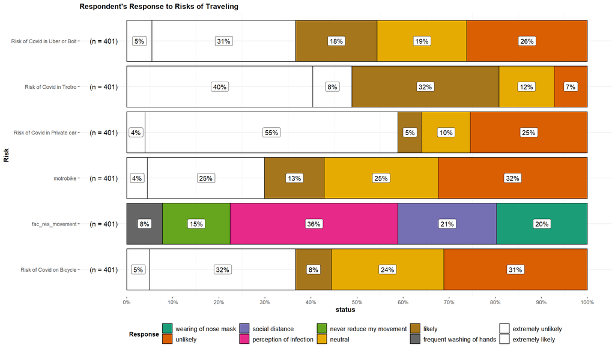

## Multinomial Logistic Regression

# @ before covid

## We now split the dataset into train and test using “sample_frac()” function from {dplyr} package

# Using sample_frac to create 70 - 30 slipt into test and train

# Another way of spliting the data

# Benchmark or reference

## model

```
Call:
multinom(formula = mode_transport ~ primary_trips + gender +
    age + edu_level + marital_status + employ_status, data = before)

Coefficients:
                  (Intercept) primary_tripsshopping primary_tripsstudy
Paratransit          4.810315              15.14049        -0.03918391
Private_transport    2.786763              14.77190         0.26902053
Ride_hailing         1.145325              15.78062        -0.21602452
                  primary_tripswork  genderMale age25 - 30 years
Paratransit               0.5577615 -0.35595182      -0.21004105
Private_transport         0.4299208 -0.08204138      -0.50045099
Ride_hailing             -0.3956315 -0.79496093       0.06630833
                  age31 - 40 years age41 - 50 years age51 - 60 years
Paratransit               1.413133       -0.3147210     -3.328237470
Private_transport         1.200526        0.4629903     -0.477446024
Ride_hailing              1.127770       -0.6688093     -0.001580779
                  age61 and above ageunder 18 edu_levelhigh school certififcate
Paratransit              9.419343   0.7089661                        -1.2725352
Private_transport       10.992166 -14.8401156                        -1.9328261
Ride_hailing            -6.690420 -15.2518581                        -0.5791623
                  edu_levelHND/diploma edu_leveljunior high certificate
Paratransit                -0.01803108                        -2.609267
Private_transport          -0.45781289                        -3.815663
Ride_hailing                0.70148175                        -1.339544
                  edu_levelno certificate and can not read
Paratransit                                      -3.446534
Private_transport                                -3.580986
Ride_hailing                                    -22.117593
                  edu_levelpostgraduate marital_statusDivorced
Paratransit                  -1.1383307              10.331898
Private_transport            -0.6677768              -3.453574
Ride_hailing                 -0.4573264              -3.053701
                  marital_statusMarried marital_statusseparated
Paratransit                   0.3608509              14.4804873
Private_transport             1.8285478              -0.7042954
Ride_hailing                  0.9233415              -1.4642131
                  marital_statusSingle employ_statusSelf Employed
Paratransit                 -0.2773978                 -0.8263034
Private_transport            0.4923332                 -0.3931386
```

[output cut: 39 more lines]

```
                  marital_statusMarried marital_statusseparated
Paratransit                    1.464947            2.078943e-06
Private_transport              1.787366            2.539181e-08
Ride_hailing                   1.879942            3.016571e-08
                  marital_statusSingle employ_statusSelf Employed
Paratransit                   1.222788                  0.9193655
Private_transport             1.590147                  0.9531525
Ride_hailing                  1.621697                  1.1456086
                  employ_statusStudent employ_statusUnemployed
Paratransit                   0.948008               0.9954285
Private_transport             1.069716               1.1149037
Ride_hailing                  1.155599               1.3369930

Residual Deviance: 600.8893
AIC: 738.8893
```

# Odds

```
                  (Intercept) primary_tripsshopping primary_tripsstudy
Paratransit        122.770314               3762108          0.9615738
Private_transport   16.228396               2602272          1.3086820
Ride_hailing         3.143463               7135670          0.8057155
                  primary_tripswork genderMale age25 - 30 years
Paratransit               1.7467580  0.7005064        0.8105510
Private_transport         1.5371357  0.9212338        0.6062572
Ride_hailing              0.6732548  0.4515989        1.0685561
                  age31 - 40 years age41 - 50 years age51 - 60 years
Paratransit               4.108809        0.7299925       0.03585625
Private_transport         3.321865        1.5888179       0.62036577
Ride_hailing              3.088760        0.5123183       0.99842047
                  age61 and above  ageunder 18
Paratransit          1.232448e+04 2.031889e+00
Private_transport    5.940692e+04 3.589382e-07
Ride_hailing         1.242761e-03 2.377947e-07
                  edu_levelhigh school certififcate edu_levelHND/diploma
Paratransit                               0.2801206            0.9821305
Private_transport                         0.1447386            0.6326658
Ride_hailing                              0.5603676            2.0167388
                  edu_leveljunior high certificate
Paratransit                             0.07358847
Private_transport                       0.02202311
Ride_hailing                            0.26196497
                  edu_levelno certificate and can not read
Paratransit                                   3.185586e-02
Private_transport                             2.784823e-02
Ride_hailing                                  2.479999e-10
                  edu_levelpostgraduate marital_statusDivorced
Paratransit                   0.3203533           3.069632e+04
Private_transport             0.5128474           3.163238e-02
Ride_hailing                  0.6329737           4.718399e-02
                  marital_statusMarried marital_statusseparated
Paratransit                    1.434550            1.944445e+06
Private_transport              6.224840            4.944569e-01
Ride_hailing                   2.517689            2.312599e-01
                  marital_statusSingle employ_statusSelf Employed
Paratransit                   0.757753                  0.4376642
Private_transport             1.636129                  0.6749352
Ride_hailing                  1.210654                  0.8868770
                  employ_statusStudent employ_statusUnemployed
Paratransit                 0.22069913               0.2362659
Private_transport           0.04894052               0.1367848
Ride_hailing                0.99079161               0.3194933
```

## p-value

```
                  (Intercept) primary_tripsshopping primary_tripsstudy
Paratransit       0.004106918                     0          0.9626057
Private_transport 0.168622892                     0          0.7857378
Ride_hailing      0.589050240                     0          0.8412099
                  primary_tripswork genderMale age25 - 30 years
Paratransit               0.4887493  0.4749037        0.7401406
Private_transport         0.6483516  0.8848529        0.5069900
Ride_hailing              0.7131573  0.2182338        0.9378191
                  age31 - 40 years age41 - 50 years age51 - 60 years
Paratransit              0.2294472        0.8214099       0.05791297
Private_transport        0.3452350        0.7534382       0.75752021
Ride_hailing             0.4635633        0.7238342       0.99932059
                  age61 and above ageunder 18 edu_levelhigh school certififcate
Paratransit                     0   0.5508279                        0.09626106
Private_transport               0   0.0000000                        0.02267328
Ride_hailing                    0   0.0000000                        0.53029302
                  edu_levelHND/diploma edu_leveljunior high certificate
Paratransit                  0.9879504                     0.0020599070
Private_transport            0.7155152                     0.0004027995
Ride_hailing                 0.6026476                     0.2308599912
                  edu_levelno certificate and can not read
Paratransit                                   0.0003800785
Private_transport                             0.0011103720
Ride_hailing                                  0.0000000000
                  edu_levelpostgraduate marital_statusDivorced
Paratransit                   0.3719147                      0
Private_transport             0.6144244                      0
Ride_hailing                  0.7663467                      0
                  marital_statusMarried marital_statusseparated
Paratransit                   0.8054318                       0
Private_transport             0.3062886                       0
Ride_hailing                  0.6233173                       0
                  marital_statusSingle employ_statusSelf Employed
Paratransit                  0.8205352                  0.3687722
Private_transport            0.7568539                  0.6800013
Ride_hailing                 0.9061651                  0.9165420
                  employ_statusStudent employ_statusUnemployed
Paratransit                0.110976160               0.1472194
Private_transport          0.004794651               0.0743715
Ride_hailing               0.993612671               0.3934254
```

# Predicting and Accuracy the class on train dataset.

```
[1] 72.05
```

## Predicting and Accuracy the class on test dataset.

```
[1] 73.42
```

# Prediction

```
  Non_motorized_transport Paratransit Private_transport Ride_hailing
1             0.303603471   0.4818400        0.21455650 7.726493e-11
2             0.034353354   0.8630494        0.06321396 3.938330e-02
3             0.003066641   0.8064570        0.15764580 3.283053e-02
4             0.029933528   0.8050538        0.15394696 1.106574e-02
5             0.007757175   0.2152062        0.76979265 7.243928e-03
6             0.170370054   0.6600163        0.03863166 1.309820e-01
```

# Misclassification error

```
                          Non_motorized_transport Paratransit Private_transport
  Non_motorized_transport                       2           1                 0
  Paratransit                                  20         263                54
  Private_transport                             3           7                25
  Ride_hailing                                  0           0                 0

                          Ride_hailing
  Non_motorized_transport            0
  Paratransit                       24
  Private_transport                  2
  Ride_hailing                       0
```

263 respondents were classified as Paratransiters and the model confirms that is true. However, 2 of them were classified as Ride_hailing but the model says they are Private_transporters. etc

# Misclassification Error Percentage

```
[1] 27.68
```

# Another way of spliting the data

# Benchmark or reference

## model

```
Call:
multinom(formula = transport_mode ~ primary_trips + gender +
    age + edu_level + marital_status + employ_status, data = during)

Coefficients:
                   (Intercept) primary_tripsshopping primary_tripsstudy
Paratransit           19.35848              15.26917          0.6831858
private transport.    19.46751              14.49447          0.4307361
Ride hailing          17.39033              15.31997          1.2404601
                   primary_tripswork genderMale age25 - 30 years
Paratransit                 2.297779  -1.163298        1.0658292
private transport.          2.064615  -1.540170        0.3739856
Ride hailing                2.926295  -2.224740        1.3003080
                   age31 - 40 years age41 - 50 years age51 - 60 years
Paratransit              -0.9522897         6.574390         7.052945
private transport.       -1.3443478         7.239509         8.281867
Ride hailing             -1.5687151         5.322238         7.747209
                   age61 and above ageunder 18
Paratransit             -41.132272   14.599333
private transport.       -5.720097   -9.856763
Ride hailing            -41.525387   14.449733
                   edu_levelhigh school certififcate edu_levelHND/diploma
Paratransit                                0.7514611             15.94034
private transport.                        -0.6198960             15.35042
Ride hailing                               1.0721148             17.21886
                   edu_leveljunior high certificate
Paratransit                              -1.2415313
private transport.                       -4.0104717
Ride hailing                             -0.8817279
                   edu_levelno certificate and can not read
Paratransit                                       -4.189514
private transport.                                -5.568710
Ride hailing                                      -3.665049
                   edu_levelpostgraduate marital_statusDivorced
Paratransit                     15.81451               11.58392
private transport.              15.86872               12.92711
Ride hailing                    15.18152              -12.77344
                   marital_statusMarried marital_statusseparated
Paratransit                     1.689335               -9.983104
private transport.              2.264696               -1.881623
```

[output cut: 43 more lines]

```
                   marital_statusMarried marital_statusseparated
Paratransit                     3.865294            3.151713e-09
private transport.              3.938447            8.139301e-08
Ride hailing                    3.902107            1.273927e-05
                   marital_statusSingle employ_statusSelf Employed
Paratransit                    3.642612                   1.472163
private transport.             3.712872                   1.489402
Ride hailing                   3.673673                   1.486421
                   employ_statusStudent employ_statusUnemployed
Paratransit                    1.168552                1.220432
private transport.             1.218383                1.267948
Ride hailing                   1.191983                1.255806

Residual Deviance: 707.4576
AIC: 845.4576
```

Dependent: transport_mode

Non motorized transport

Paratransit

private transport.

Ride hailing

OR (univariable)

OR (multivariable)

Primary trip

others

4 (9.3)

23 (53.5)

9 (20.9)

7 (16.3)

study

3 (2.4)

66 (53.2)

21 (16.9)

34 (27.4)

4.14 (0.88-21.77, p=0.071)

2.23 (0.17-24.96, p=0.506)

work

4 (2.0)

101 (50.2)

52 (25.9)

44 (21.9)

5.05 (1.15-22.20, p=0.026)

11.51 (0.94-166.60, p=0.056)

shopping

22 (66.7)

6 (18.2)

5 (15.2)

32242668.29 (0.00-NA, p=0.993)

87914079.74 (0.00-NA, p=0.998)

Gender

Female

5 (2.9)

75 (44.1)

34 (20.0)

56 (32.9)

Male

6 (2.6)

137 (59.3)

54 (23.4)

34 (14.7)

1.14 (0.32-3.83, p=0.835)

0.22 (0.02-1.30, p=0.131)

Age

18 - 24 years

6 (5.0)

63 (52.1)

16 (13.2)

36 (29.8)

25 - 30 years

1 (0.6)

98 (57.3)

31 (18.1)

41 (24.0)

8.87 (1.49-168.68, p=0.045)

2.86 (0.28-76.43, p=0.431)

31 - 40 years

3 (6.0)

29 (58.0)

12 (24.0)

6 (12.0)

0.82 (0.21-4.00, p=0.782)

0.32 (0.03-4.59, p=0.361)

61 and above

1 (33.3)

2 (66.7)

0.10 (0.01-2.43, p=0.081)

0.00 (0.00-0.41, p=0.045)

41 - 50 years

14 (38.9)

20 (55.6)

2 (5.6)

16401705.02 (0.00-NA, p=0.993)

4056500.03 (0.00-NA, p=0.998)

51 - 60 years

3 (25.0)

7 (58.3)

2 (16.7)

16401705.02 (0.00-NA, p=0.996)

6975471.27 (0.00-NA, p=0.999)

under 18

5 (62.5)

3 (37.5)

16401705.02 (0.00-NA, p=0.997)

203323414.06 (0.00-NA, p=0.999)

Education Level

first degree

2 (1.4)

75 (54.0)

41 (29.5)

21 (15.1)

high school certififcate

2 (1.9)

60 (56.1)

15 (14.0)

30 (28.0)

0.77 (0.09-6.47, p=0.792)

2.04 (0.12-62.26, p=0.627)

junior high certificate

1 (2.8)

22 (61.1)

2 (5.6)

11 (30.6)

0.51 (0.05-11.18, p=0.588)

0.24 (0.01-9.90, p=0.412)

no certificate and can not read

6 (24.0)

10 (40.0)

4 (16.0)

5 (20.0)

0.05 (0.01-0.22, p<0.001)

0.01 (0.00-0.31, p=0.011)

HND/diploma

27 (45.0)

12 (20.0)

21 (35.0)

12474969.76 (0.00-NA, p=0.994)

56709979.83 (0.00-NA, p=0.997)

postgraduate

18 (52.9)

14 (41.2)

2 (5.9)

12474969.99 (0.00-NA, p=0.996)

194406863.94 (0.00-NA, p=0.998)

Marital status

Cohabitation

1 (6.7)

8 (53.3)

2 (13.3)

4 (26.7)

Married

2 (1.7)

51 (44.3)

44 (38.3)

18 (15.7)

4.04 (0.18-44.84, p=0.267)

6.88 (0.01-7986.59, p=0.619)

Single

8 (3.0)

151 (56.6)

41 (15.4)

67 (25.1)

2.31 (0.12-13.95, p=0.444)

1.45 (0.00-539.09, p=0.918)

Divorced

2 (66.7)

1 (33.3)

1117954.34 (0.00-NA, p=0.992)

18.53 (0.00-Inf, p=1.000)

separated

1 (100.0)

1117954.34 (0.00-NA, p=0.995)

237856489.38 (0.00-NA, p=1.000)

Employment status

Self Employed

3 (2.8)

51 (47.7)

29 (27.1)

24 (22.4)

Student

3 (2.8)

60 (56.1)

10 (9.3)

34 (31.8)

Unemployed

5 (10.6)

24 (51.1)

7 (14.9)

11 (23.4)

Formally Employed

77 (55.0)

42 (30.0)

21 (15.0)

| x |
| --- |
| Number in dataframe = 401, Number in model = 401, Missing = 0, AIC = 94.6, C-statistic = 0.965, H&L = Chi-sq(8) 1.06 (p=0.998) |

#Odds

```
                   (Intercept) primary_tripsshopping primary_tripsstudy
Paratransit          255434538               4278735           1.980176
private transport.   284859268               1971832           1.538390
Ride hailing          35688267               4501704           3.457204
                   primary_tripswork genderMale age25 - 30 years
Paratransit                 9.952056  0.3124539         2.903245
private transport.          7.882262  0.2143447         1.453516
Ride hailing               18.658373  0.1080955         3.670427
                   age31 - 40 years age41 - 50 years age51 - 60 years
Paratransit               0.3858565         716.5085         1156.259
private transport.        0.2607097        1393.4094         3951.564
Ride hailing              0.2083127         204.8418         2315.102
                   age61 and above  ageunder 18
Paratransit           1.369245e-18 2.189826e+06
private transport.    3.279394e-03 5.239165e-05
Ride hailing          9.241735e-19 1.885555e+06
                   edu_levelhigh school certififcate edu_levelHND/diploma
Paratransit                                2.1200954              8371448
private transport.                         0.5380004              4640884
Ride hailing                               2.9215513             30064771
                   edu_leveljunior high certificate
Paratransit                              0.28894143
private transport.                       0.01812484
Ride hailing                             0.41406683
                   edu_levelno certificate and can not read
Paratransit                                     0.015153646
private transport.                              0.003815401
Ride hailing                                    0.025602927
                   edu_levelpostgraduate marital_statusDivorced
Paratransit                      7381668           1.073574e+05
private transport.               7792861           4.113124e+05
Ride hailing                     3919687           2.835077e-06
                   marital_statusMarried marital_statusseparated
Paratransit                     5.415880            4.617352e-05
private transport.              9.628196            1.523426e-01
Ride hailing                    8.850539            5.680733e+06
                   marital_statusSingle employ_statusSelf Employed
Paratransit                    1.300419               1.076698e-07
private transport.             1.517832               2.440069e-07
Ride hailing                   1.577941               1.953251e-07
                   employ_statusStudent employ_statusUnemployed
Paratransit                4.178715e-08            2.232126e-08
private transport.         1.302653e-08            2.221632e-08
Ride hailing               1.077256e-07            3.716012e-08
```

## p-value

```
                    (Intercept) primary_tripsshopping primary_tripsstudy
Paratransit        2.831668e-11                     0          0.5754265
private transport. 8.582357e-11                     0          0.7377774
Ride hailing       4.392060e-09                     0          0.3352280
                   primary_tripswork genderMale age25 - 30 years
Paratransit               0.07661085 0.24631975        0.4250110
private transport.        0.12529808 0.13542077        0.7864680
Ride hailing              0.03065233 0.02933409        0.3397114
                   age31 - 40 years age41 - 50 years age51 - 60 years
Paratransit               0.4490009        0.9612911                0
private transport.        0.3147616        0.9573787                0
Ride hailing              0.2436021        0.9686597                0
                   age61 and above ageunder 18
Paratransit               0.000000           0
private transport.        0.113094         NaN
Ride hailing              0.000000           0
                   edu_levelhigh school certififcate edu_levelHND/diploma
Paratransit                                0.6093235                    0
private transport.                         0.6820891                    0
Ride hailing                               0.4729061                    0
                   edu_leveljunior high certificate
Paratransit                              0.48019898
private transport.                       0.03744264
Ride hailing                             0.62306986
                   edu_levelno certificate and can not read
Paratransit                                     0.013456769
private transport.                              0.001934087
Ride hailing                                    0.034208046
                   edu_levelpostgraduate marital_statusDivorced
Paratransit                            0                      0
private transport.                     0                      0
Ride hailing                           0                      0
                   marital_statusMarried marital_statusseparated
Paratransit                    0.6620734                       0
private transport.             0.5652761                       0
Ride hailing                   0.5763016                       0
                   marital_statusSingle employ_statusSelf Employed
Paratransit                   0.9425105                          0
private transport.            0.9105156                          0
Ride hailing                  0.9011891                          0
                   employ_statusStudent employ_statusUnemployed
Paratransit                           0                       0
private transport.                    0                       0
Ride hailing                          0                       0
```

# Accuracy

```
[1] 61.6
```

## Predicting and Accuracy the class on test dataset.

```
[1] 67.09
```

# Prediction

```
  Non motorized transport Paratransit private transport. Ride hailing
1            2.542356e-01   0.4284591         0.17290053  0.144404774
2            1.517140e-02   0.6548326         0.14436848  0.185627527
3            2.059691e-15   0.6905218         0.23095472  0.078523459
4            2.246921e-02   0.5180460         0.36465116  0.094833639
5            6.924137e-20   0.3134584         0.67997918  0.006562411
6            3.727155e-02   0.6786228         0.03724107  0.246864608
```

# Misclassification error

```
                          Non motorized transport Paratransit
  Non motorized transport                       5           2
  Paratransit                                   6         181
  private transport.                            0          10
  Ride hailing                                  0          19

                          private transport. Ride hailing
  Non motorized transport                  0            0
  Paratransit                             51           55
  private transport.                      30            4
  Ride hailing                             7           31
```

181 respondents were classified as Paratransiters and the model confirms that is true. However, 2 of them were classified as Paratransiters but the model says they are Non motorized transporters.

# Misclassification Error Percentage

```
[1] 38.4
```